# DABI_44_MA7419_CW2

## Table of contents

## DATA ANALYSIS ON DATASET

- Data collection: The data set are taken from the in build stats19 package. The road accident by casualty for 2017,2018,2019 and 2020 are used in this project to make analysis
- Data cleaning: An important step in data analysis is data cleaning. Because uncleaned data can provide wrong results.In this data set null values are checked.
- Data structuring: An unstructured data cannot be used to do data analysis. So, when a particular method is performed its structured according to the values needed
- Exploratory data analysis: The exploratory data analysis is done to know more about the dataset and interpret over questions

## Exploratory data analysis

This graphs created to understand the data deeply.

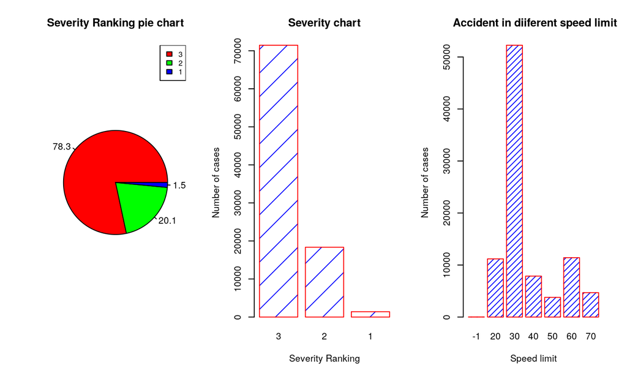

## Questions to be asked in the project

- In which day of a week most accident happens over the past four years?
- At which junction detail more number of accident happens for the past four years?
- What are local authority district that had more number of accidents?
- Which vechicle are involved in accidents based on severity?

## ACCIDENTS AT DIFFERENT DAYS OF A WEEK

This graph shows the days of a week where accident happened for four years

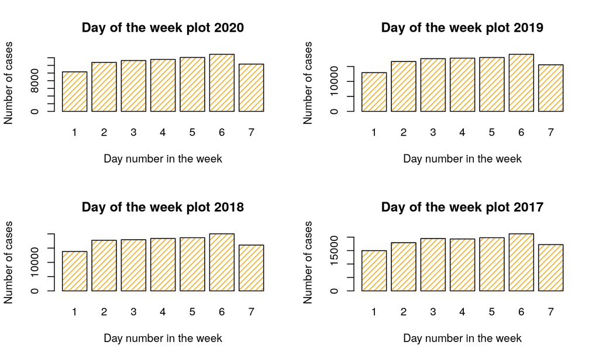

## ACCIDENTS AT DIFFERENT JUCTION DETAIL

This grpah shows the top 3 junction detail where the most number of accidents happened

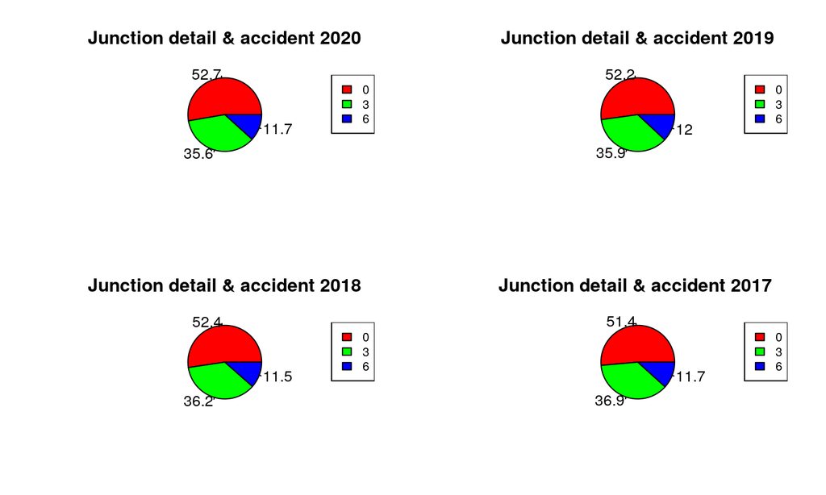

## What are local auhority district that had more number of accidents?

-For the year 2020 these are the areas with most accidents: Kent - E10000016 - 2964 Surrey - E10000030 - 2334 Essex - E10000012 - 2064

-For the year 2019 these are the areas with most accidents: Kent - E10000016 - 3619 Surrey - E10000030 - 2964 Birmingham - E08000025 - 2623

-For the year 2018 these are the areas with most accidents: Kent - E10000016 - 3798 Surrey - E10000030 - 3111 Hampshire - E10000014 - 2615

-For the past three years, Kent and Surrey area has the most number of accident cases in the United Kingdom.

## TOP TWO HIGHWAYS ACCIDENT HAPPENED

The graph shows the highest highways that had accidents

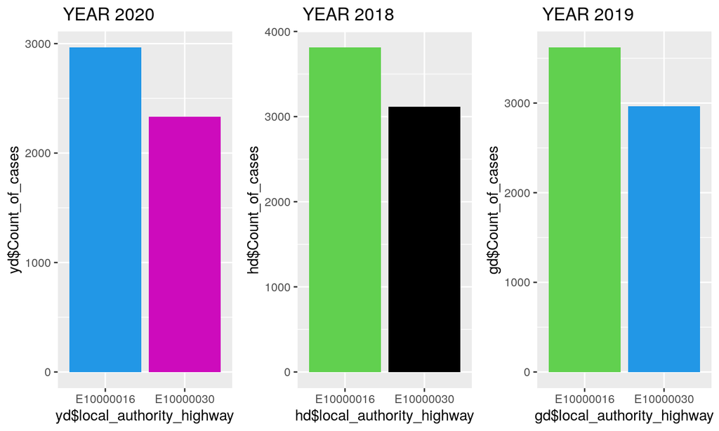

## Which vechiles are invloved in accidents based on severity?

- Based on the analysis, the top categories of vehicles which caused accident are are found based on severity.
- The car/Taxi/minibuses are the vehickle category which had more number of accidents

## Top vehicle category which are involved in accident

The graph shows the top three accidented vechicle category

[figure not shown]

## Methods Used

- Library used : ggplot, tidyverse, stats19, knitr, ggpubr
- Linear regression, correlation
- ggplot2, pie, bar plot
- as.data.frame, head, read.csv, read.excel, knitr :: kable(), groupby, round

## Conclusion

- The graph shows that the accidents are decreasing year by year and if we control the peak categories, it reduces more.

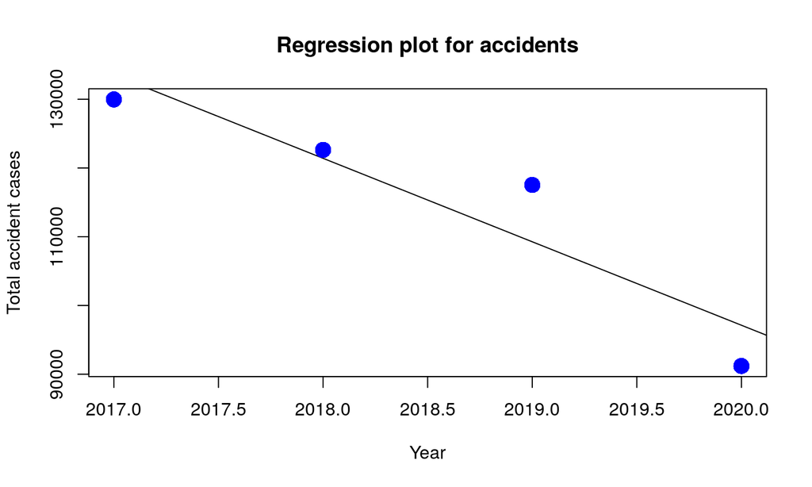